# Pooled Forecast Models

Setting up the R workspace

# Starting with the Copper River Delta (CRD)

## RCP 4.5

### Design the Model

Then separate the data into air and water temperature files

[output not shown]

Setting up the random walk model

```r
dlm_pooled <- "
model{
#### Priors
for(p in 1:np){
x[1,p] ~ dnorm(x_ic, tau_ic) # Initial condition of water temperature
}
tau_obs ~ dgamma(a_obs, r_obs) # Prior on observation error
tau_add ~ dgamma(a_add, r_add) # Prior on process error

#### Fixed Effects
beta ~ dmnorm(mu_beta, tau_beta) # Prior on beta coefficients

for(p in 1:np){
int[p] ~ dnorm(mu_int, tau_int) # Prior on pond-specific intercepts
}

#### Data Model
for(t in 1:n){ # loop over all time steps
for(p in 1:np){
OBS[t,p] ~ dnorm(x[t,p], tau_obs) # Observed water temperature is drawn from latent air temperature with observation uncertainty
}
Xf[t] ~ dnorm(muAirTemp[t], tauAirTemp[t]) # Latent air temperature is drawn from mean and precision of forecasated air temperature
}

#### Process Model
for(t in 2:n){ # loop over all time steps except teh first (we defined ic above)
for(p in 1:np){
mu[t,p] <- x[t-1,p] + int[p] + beta[1] * x[t-1,p] + beta[2] * Xf[t] # Mean water temperature is a function of the previous time step and current air temperature
x[t,p] ~ dnorm(mu[t,p], tau_add) # Latent water temperature is drawn from mean water temperature with process uncertainty
}
}
}
"
```

Define the data and priors for the model

```r
# Empty list
data <- list()
# Water temperature observations
data$OBS <- dplyr::select(CR_WaterTemp45, -date)
# Number of time steps
data$n <- nrow(data$OBS)
# Number of ponds
data$np <- ncol(data$OBS)
# Initial water temperature mean
data$x_ic <- 0.1
# Initial water temperature precision
data$tau_ic = 0.1
# Prior parameters for observation and process uncertainty
data$a_obs = 1
data$r_obs = 1
data$a_add = 1
data$r_add = 1
# Prior parameters for beta coefficients
data$mu_beta <- c(0, 0)
data$tau_beta <- diag(x = c(0.001, 0.001), nrow = 2, ncol = 2)
# Prior parameters for intercept
data$mu_int <- 0
data$tau_int <- 0.001
# Mean air temperature estimate
data$muAirTemp <- CR_AirTemp45$Air_MonthAvg
# Air temperature precision
data$tauAirTemp <- CR_AirTemp45$precision
```

Create JAGS model with 3 chains

```r
jm <- jags.model(file = textConnection(dlm_pooled), data = data, n.chains = 3)
```

Posterior samples of parameters

```r
CRD45_out_params <- coda.samples(model = jm,
                               variable.names = c('beta', 'int',
                                                  'tau_add', 'tau_obs'),
                               n.iter = 50000, thin = 25)
```

Posterior samples of response variables

```r
CRD45_out_response <- coda.samples(model = jm,
                                 variable.names = c('x', 'OBS'),
                                 n.iter = 100000, thin = 25)
```

A couple quick checks here

```r
# plot(CRD45_out_params)
gelman.diag(CRD45_out_params, confidence = 0.99)
```

Visualize the output by just looking at the **95% credible interval of the time-series of X’s** and compare that to the observed Y’s

Transform the samples back from the log domain to the linear domain

```r
time                               ## adjust to zoom in and out
time <-as.Date(time)
out <- as.matrix(CRD45_out_response)         ## convert from coda to matrix
```

code from AMW for splitting up this matrix

```r
x_cols <- grep('^x', colnames(out))
obs_cols <- grep('^OBS', colnames(out))

out_x <- out[,x_cols]
out_obs <- out[,obs_cols]

rm(out)

out_x <- t(out_x)

out_x <- as.data.frame(out_x)
out_x2 <- out_x |>
  tibble::rownames_to_column(var = 'time_pond') |>
  dplyr::mutate(timestep = sub(x = time_pond,
                               pattern = '.*x\\[',
                               replacement = ''),
                timestep = sub(x = timestep,
                               pattern = ',.*',
                               replacement = ''),
                pond = sub(x = time_pond,
                           pattern = '.*,',
                           replacement = ''),
                pond = sub(x = pond,
                           pattern = '\\]',
                           replacement = '')) |>
  tidyr::pivot_longer(-c(time_pond, timestep, pond),
                      names_to = 'iter', values_to = 'val') |>
  dplyr::group_by(pond, timestep) |>
  dplyr::summarize(low = quantile(val, probs = 0.025),
                   med = median(val),
                   high = quantile(val, probs = 0.975))

timesteps <- as.data.frame(time)
timesteps$ind <- as.character(seq(from = 1, to = nrow(timesteps), by = 1))
colnames(timesteps) <- c('time', 'timestep')

ponds <- as.data.frame(colnames(CR_WaterTemp45[-1]))
ponds$ind <- as.character(seq(from = 1, to = nrow(ponds), by = 1))
colnames(ponds) <- c('pond_name', 'pond')

out_x_mapped <- out_x2 |>
  dplyr::left_join(y = timesteps, by = 'timestep') |>
  dplyr::left_join(y = ponds, by = 'pond') |>
  dplyr::select(low, med, high, time, pond_name)

pX <- out_x_mapped |>
  ggplot2::ggplot() +
  ggplot2::geom_line(ggplot2::aes(x = time, y = med)) +
  ggplot2::geom_ribbon(ggplot2::aes(x = time, ymin = low, ymax = high)) +
  ggplot2::facet_wrap(~pond_name)

out_obs <- t(out_obs)

out_obs <- as.data.frame(out_obs)

out_obs2 <- out_obs |>
  tibble::rownames_to_column(var = 'time_pond') |>
  dplyr::mutate(timestep = sub(x = time_pond,
                               pattern = '.*OBS\\[',
                               replacement = ''),
                timestep = sub(x = timestep,
                               pattern = ',.*',
                               replacement = ''),
                pond = sub(x = time_pond,
                           pattern = '.*,',
                           replacement = ''),
                pond = sub(x = pond,
                           pattern = '\\]',
                           replacement = '')) |>
  tidyr::pivot_longer(-c(time_pond, timestep, pond),
                      names_to = 'iter', values_to = 'val') |>
  dplyr::group_by(pond, timestep) |>
  dplyr::summarize(low = quantile(val, probs = 0.025),
                   med = median(val),
                   high = quantile(val, probs = 0.975))

out_obs_mapped <- out_obs2 |>
  dplyr::left_join(y = timesteps, by = 'timestep') |>
  dplyr::left_join(y = ponds, by = 'pond') |>
  dplyr::select(low, med, high, time, pond_name)

pOBS <- out_obs_mapped |>
  ggplot2::ggplot() +
  ggplot2::geom_line(ggplot2::aes(x = time, y = med)) +
  ggplot2::geom_ribbon(ggplot2::aes(x = time, ymin = low, ymax = high)) +
  ggplot2::facet_wrap(~pond_name)

cowplot::plot_grid(pX, pOBS)
```

### Probability of Crossing Threshold

```r
threshold_probs <- out_obs |>
  tibble::rownames_to_column(var = 'time_pond') |>
  dplyr::mutate(timestep = sub(x = time_pond,
                               pattern = '.*OBS\\[',
                               replacement = ''),
                timestep = sub(x = timestep,
                               pattern = ',.*',
                               replacement = ''),
                pond = sub(x = time_pond,
                           pattern = '.*,',
                           replacement = ''),
                pond = sub(x = pond,
                           pattern = '\\]',
                           replacement = '')) |>
  tidyr::pivot_longer(-c(time_pond, timestep, pond),
                      names_to = 'iter', values_to = 'val') |>
  dplyr::group_by(pond, timestep) |>
  dplyr::summarize(n_iter = dplyr::n(),
                   n_thresh = sum(val > 20),
                   prob = (n_thresh / n_iter) * 100)

threshold_probs_mapped <- threshold_probs |>
  dplyr::left_join(y = timesteps, by = 'timestep') |>
  dplyr::left_join(y = ponds, by = 'pond')

threshold_probs_mapped |>
  ggplot2::ggplot() +
  ggplot2::geom_line(ggplot2::aes(x = time, y = prob)) +
  ggplot2::facet_wrap(~pond_name)
```

Save these ouputs using a .RDataFile type

```r
save.image(file = "PooledMod_CRD45.RData")

#Currently this has all the information in it. Eventually could limit this to be just the relavent information for the remaining code below
```

### Making Graphs

Load in this file here as long as no code changes are needed above

```r
load(file = "PooledMod_CRD45.RData")
```

Creating some nice plots of these

1. colored panel plot (each ponds forecast with the median, high, and low plus a trend line)

```r
# set up the colors here for the plots below so that each pond has the same color each time
Mod_CRD45 <- out_obs_mapped
str(Mod_CRD45)
```

```
gropd_df [9,612 × 6] (S3: grouped_df/tbl_df/tbl/data.frame)
 $ pond     : chr [1:9612] "1" "1" "1" "1" ...
 $ low      : Named num [1:9612] -6.4 6.28 -3.108 -0.108 2.916 ...
  ..- attr(*, "names")= chr [1:9612] "2.5%" "2.5%" "2.5%" "2.5%" ...
 $ med      : num [1:9612] -0.276 6.28 0.562 3.362 6.294 ...
 $ high     : Named num [1:9612] 5.88 6.28 4.06 6.76 9.51 ...
  ..- attr(*, "names")= chr [1:9612] "97.5%" "97.5%" "97.5%" "97.5%" ...
 $ time     : Date[1:9612], format: "2012-01-01" "2012-10-01" "2020-04-01" ...
 $ pond_name: chr [1:9612] "BVS" "BVS" "BVS" "BVS" ...
 - attr(*, "groups")= tibble [9 × 2] (S3: tbl_df/tbl/data.frame)
  ..$ pond : chr [1:9] "1" "2" "3" "4" ...
  ..$ .rows: list<int> [1:9]
  .. ..$ : int [1:1068] 1 2 3 4 5 6 7 8 9 10 ...
  .. ..$ : int [1:1068] 1069 1070 1071 1072 1073 1074 1075 1076 1077 1078 ...
  .. ..$ : int [1:1068] 2137 2138 2139 2140 2141 2142 2143 2144 2145 2146 ...
  .. ..$ : int [1:1068] 3205 3206 3207 3208 3209 3210 3211 3212 3213 3214 ...
  .. ..$ : int [1:1068] 4273 4274 4275 4276 4277 4278 4279 4280 4281 4282 ...
  .. ..$ : int [1:1068] 5341 5342 5343 5344 5345 5346 5347 5348 5349 5350 ...
  .. ..$ : int [1:1068] 6409 6410 6411 6412 6413 6414 6415 6416 6417 6418 ...
  .. ..$ : int [1:1068] 7477 7478 7479 7480 7481 7482 7483 7484 7485 7486 ...
  .. ..$ : int [1:1068] 8545 8546 8547 8548 8549 8550 8551 8552 8553 8554 ...
  .. ..@ ptype: int(0)
  ..- attr(*, ".drop")= logi TRUE
```

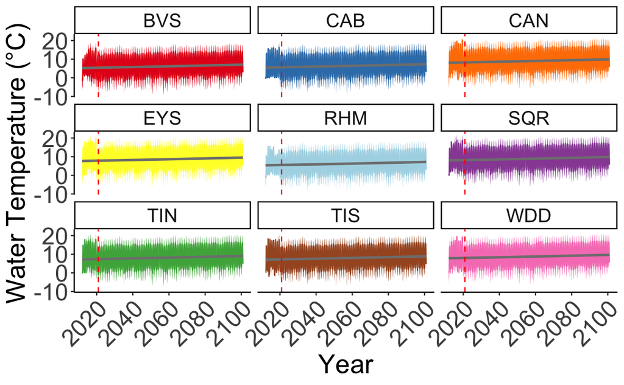

```r
write.csv(Mod_CRD45, "Mod_CRD45.csv")

# Define the custom color palette
CR_colors <- c("#E41A1C", "#377EB8", "#4DAF4A", "#984EA3", "#FF7F00", "#FFFF33", "#A65628", "#F781BF", "lightblue")

# Ensure that CR_colors has the same length as the number of unique ponds
unique_ponds <- unique(Mod_CRD45$pond_name)
if (length(CR_colors) != length(unique_ponds)) {
  stop("The number of colors in CR_colors does not match the number of unique ponds.")
}

# Create a named vector for CR_colors with pond names
color_mapping <- setNames(CR_colors, unique_ponds)

# Plotting
Ponds_CRD45 <- ggplot(data = Mod_CRD45, aes(x = time)) +
  geom_ribbon(aes(ymin = low, ymax = high, fill = pond_name)) +  # Add the ribbon with colors
  geom_line(aes(y = med, color = pond_name)) +  # Ensure lines are visible and colored by pond
  geom_smooth(aes(y = med, color = "grey"), size = 1) +  # Ensure lines are visible and colored by pond
  geom_vline(xintercept = as.Date("2020-12-01"), linetype = "dashed", color = "red") +  # Add vertical dashed red line
  facet_wrap(~ pond_name) +  # Facet by pond_name
  scale_color_manual(values = color_mapping) +  # Use custom colors for lines
  scale_fill_manual(values = color_mapping) +   # Use custom colors for ribbons
  xlab("Year") +
  ylab("Water Temperature (°C)") +
  theme_classic() +
  theme(plot.title = element_text(hjust = 0.5, size = 24),
        axis.title = element_text(size = 22),
        axis.text = element_text(size = 20),
        axis.text.x = element_text(angle = 45, hjust = 1),
        legend.position = "none",
        strip.text = element_text(size = 16))
Ponds_CRD45
ggsave("IndPonds_CRD45.png", plot = Ponds_CRD45, width = 8, height = 6)
```

2. Trend by pond (geom smooth for each pond on the same plot for comparison)

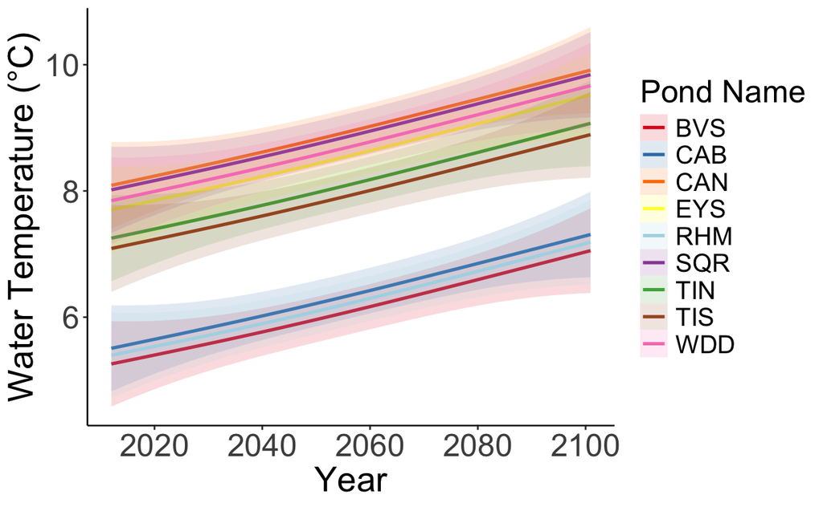

```r
# using the same aestetics as above

Trends_CRD45 <- ggplot(data = Mod_CRD45, aes(x = time)) +
  geom_smooth(aes(y = med, color = pond_name, fill = pond_name), alpha = 0.15, size = 1) +  # Smooth lines with colors by pond_name
  scale_color_manual(values = color_mapping) +
  scale_fill_manual(values = color_mapping) +   # Use custom colors for ribbons
  labs(
       x = "Year",
       y = "Water Temperature (°C)",
       color = "Pond Name",
       fill = "Pond Name") +  # Labels for legend
  theme_classic() +
  theme(plot.title = element_text(hjust = 0.5, size = 18),
        axis.title = element_text(size = 22),
        axis.text = element_text(size = 20),
        legend.position = "right",
        legend.text = element_text(size = 16), # Change the legend text size here
        legend.title = element_text(size = 20)) # Position the legend on the right
Trends_CRD45
ggsave("IndTrends_CRD45.png", plot = Trends_CRD45, width = 9, height = 6)
```

3. probability plot (by pond)

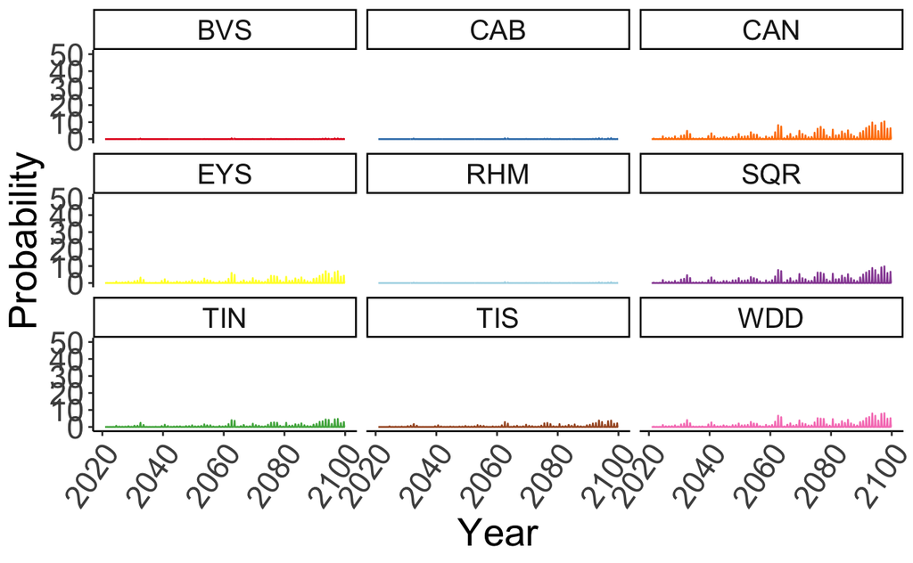

```r
probs_CRD45 <- threshold_probs_mapped
write.csv(probs_CRD45, "probs_CRD45.csv")

Probs20_CRD45 <- ggplot(data = probs_CRD45, aes(x = time)) +
  geom_line(aes(y = prob, color = pond_name)) +  # Ensure lines are visible and colored by pond
  facet_wrap(~ pond_name) +  # Facet by pond_name
  scale_color_manual(values = color_mapping) +  # Use custom colors for lines
  xlab("Year") +
  ylab("Probability") +
  xlim(as.Date(c("2020-12-01", "2099-12-01"))) +
  ylim(0,50) +
  theme_classic() +
  theme(plot.title = element_text(hjust = 0.5, size = 18),
        axis.title = element_text(size = 22),
        axis.text = element_text(size = 18),
        axis.text.x = element_text(angle = 55, hjust = 1),
        legend.position = "none",
        strip.text = element_text(size = 16))
Probs20_CRD45
ggsave("Probs20_CRD45.png", plot = Probs20_CRD45, width = 9, height = 6)
```

4. Model fits by pond

```r
Mod_CRD45
```

| pond | low | med | high | time | pond_name |
| --- | --- | --- | --- | --- | --- |
| 1 | -6.40009862 | -0.2763436711 | 5.883200 | 2012-01-01 | BVS |
| 1 | 6.28000000 | 6.2800000000 | 6.280000 | 2012-10-01 | BVS |
| 1 | -3.10816287 | 0.5618793912 | 4.061602 | 2020-04-01 | BVS |
| 1 | -0.10849712 | 3.3618905940 | 6.762596 | 2095-04-01 | BVS |
| 1 | 2.91636273 | 6.2938429296 | 9.509459 | 2095-05-01 | BVS |
| 1 | 5.85432726 | 9.7329884458 | 13.604475 | 2095-06-01 | BVS |
| 1 | 9.16619320 | 12.6381694265 | 16.304430 | 2095-07-01 | BVS |
| 1 | 10.76130497 | 14.2266597580 | 17.757312 | 2095-08-01 | BVS |
| 1 | 10.24559194 | 13.4908052822 | 16.912188 | 2095-09-01 | BVS |
| 1 | 7.52457349 | 10.8441313222 | 14.311948 | 2095-10-01 | BVS |

[output cut: 990 more lines]

```r
ModObs <- Mod_CRD45 %>%
  filter(time < "2021-01-01")
range(ModObs$time)
```

```
[1] "2012-01-01" "2020-12-01"
```

[figure not shown]

```r
ModelErrorPlot_CRD45 <- ggplot(data = ModObs, aes(x = time)) +
  geom_ribbon(aes(ymin = low, ymax = high, fill = pond_name)) +  # Adjust fill colors
  geom_line(aes(y = med), color = "black") +  # Black lines for the median values
  facet_wrap(~ pond_name) +  # Facet by pond_name
  scale_fill_manual(values = color_mapping) +  # Apply custom color palette for ribbons
  labs(
       x = "Year",
       y = "Water Temperature (°C)",
       color = "Pond Name",
       fill = "Pond Name") +  # Labels for legend
  theme_classic() +
  theme(
    plot.title = element_text(hjust = 0.5),
    axis.title = element_text(size = 16),
    axis.text = element_text(size = 14),
    axis.text.x = element_text(angle = 45, hjust = 1),
    legend.position = "none" # Angle x-axis labels if needed
  )
ModelErrorPlot_CRD85

ggsave("Error_CRD45.png", plot = ModelErrorPlot_CRD45, width = 9, height = 6)
```

Clear out the environment and reload the basics before starting the next section

```r
rm(list = ls())

library(tidyverse)
library(rjags)
library(ggplot2)

set.seed(1)
```

## RCP 8.5

### Design the Model

Then separate the data into air and water temperature files

```r
# Air and water temperature data: CR loccation, 4.5 scenario
CR_Temps <- read.csv("CR_85SNAPForecast.csv", header=TRUE)

# Air temperature variables
CR_AirTemp85 <- CR_Temps %>%
  select(date, Airport, Air_MonthAvg, std, precision, Region)

# Water temperature variables
CR_WaterTemp85 <- CR_Temps %>%
  select(date, BVS, CAB, TIN, SQR, CAN, EYS, TIS, WDD, RHM)


# Set up a string of all the dates
time <- CR_WaterTemp85$date
length(time)
```

Setting up the random walk model

```r
dlm_pooled <- "
model{
#### Priors
for(p in 1:np){
x[1,p] ~ dnorm(x_ic, tau_ic) # Initial condition of water temperature
}
tau_obs ~ dgamma(a_obs, r_obs) # Prior on observation error
tau_add ~ dgamma(a_add, r_add) # Prior on process error

#### Fixed Effects
beta ~ dmnorm(mu_beta, tau_beta) # Prior on beta coefficients

for(p in 1:np){
int[p] ~ dnorm(mu_int, tau_int) # Prior on pond-specific intercepts
}

#### Data Model
for(t in 1:n){ # loop over all time steps
for(p in 1:np){
OBS[t,p] ~ dnorm(x[t,p], tau_obs) # Observed water temperature is drawn from latent air temperature with observation uncertainty
}
Xf[t] ~ dnorm(muAirTemp[t], tauAirTemp[t]) # Latent air temperature is drawn from mean and precision of forecasated air temperature
}

#### Process Model
for(t in 2:n){ # loop over all time steps except teh first (we defined ic above)
for(p in 1:np){
mu[t,p] <- x[t-1,p] + int[p] + beta[1] * x[t-1,p] + beta[2] * Xf[t] # Mean water temperature is a function of the previous time step and current air temperature
x[t,p] ~ dnorm(mu[t,p], tau_add) # Latent water temperature is drawn from mean water temperature with process uncertainty
}
}
}
"
```

Define the data and priors for the model

```r
# Empty list
data <- list()
# Water temperature observations
data$OBS <- dplyr::select(CR_WaterTemp85, -date)
# Number of time steps
data$n <- nrow(data$OBS)
# Number of ponds
data$np <- ncol(data$OBS)
# Initial water temperature mean
data$x_ic <- 0.1
# Initial water temperature precision
data$tau_ic = 0.1
# Prior parameters for observation and process uncertainty
data$a_obs = 1
data$r_obs = 1
data$a_add = 1
data$r_add = 1
# Prior parameters for beta coefficients
data$mu_beta <- c(0, 0)
data$tau_beta <- diag(x = c(0.001, 0.001), nrow = 2, ncol = 2)
# Prior parameters for intercept
data$mu_int <- 0
data$tau_int <- 0.001
# Mean air temperature estimate
data$muAirTemp <- CR_AirTemp85$Air_MonthAvg
# Air temperature precision
data$tauAirTemp <- CR_AirTemp85$precision
```

Create JAGS model with 3 chains

```r
jm <- jags.model(file = textConnection(dlm_pooled), data = data, n.chains = 3)
```

Posterior samples of parameters

```r
CRD85_out_params <- coda.samples(model = jm,
                               variable.names = c('beta', 'int',
                                                  'tau_add', 'tau_obs'),
                               n.iter = 50000, thin = 25)
```

Posterior samples of response variables

```r
CRD85_out_response <- coda.samples(model = jm,
                                 variable.names = c('x', 'OBS'),
                                 n.iter = 100000, thin = 25)
```

A couple quick checks here

```r
# plot(CRD85_out_params)
gelman.diag(CRD85_out_params, confidence = 0.99)
```

Visualize the output by just looking at the **95% credible interval of the time-series of X’s** and compare that to the observed Y’s

Transform the samples back from the log domain to the linear domain

```r
time                               ## adjust to zoom in and out
time <-as.Date(time)
out <- as.matrix(CRD85_out_response)         ## convert from coda to matrix
```

code from AMW for splitting up this matrix

```r
x_cols <- grep('^x', colnames(out))
obs_cols <- grep('^OBS', colnames(out))

out_x <- out[,x_cols]
out_obs <- out[,obs_cols]

rm(out)

out_x <- t(out_x)

out_x <- as.data.frame(out_x)
out_x2 <- out_x |>
  tibble::rownames_to_column(var = 'time_pond') |>
  dplyr::mutate(timestep = sub(x = time_pond,
                               pattern = '.*x\\[',
                               replacement = ''),
                timestep = sub(x = timestep,
                               pattern = ',.*',
                               replacement = ''),
                pond = sub(x = time_pond,
                           pattern = '.*,',
                           replacement = ''),
                pond = sub(x = pond,
                           pattern = '\\]',
                           replacement = '')) |>
  tidyr::pivot_longer(-c(time_pond, timestep, pond),
                      names_to = 'iter', values_to = 'val') |>
  dplyr::group_by(pond, timestep) |>
  dplyr::summarize(low = quantile(val, probs = 0.025),
                   med = median(val),
                   high = quantile(val, probs = 0.975))

timesteps <- as.data.frame(time)
timesteps$ind <- as.character(seq(from = 1, to = nrow(timesteps), by = 1))
colnames(timesteps) <- c('time', 'timestep')

ponds <- as.data.frame(colnames(CR_WaterTemp85[-1]))
ponds$ind <- as.character(seq(from = 1, to = nrow(ponds), by = 1))
colnames(ponds) <- c('pond_name', 'pond')

out_x_mapped <- out_x2 |>
  dplyr::left_join(y = timesteps, by = 'timestep') |>
  dplyr::left_join(y = ponds, by = 'pond') |>
  dplyr::select(low, med, high, time, pond_name)

pX <- out_x_mapped |>
  ggplot2::ggplot() +
  ggplot2::geom_line(ggplot2::aes(x = time, y = med)) +
  ggplot2::geom_ribbon(ggplot2::aes(x = time, ymin = low, ymax = high)) +
  ggplot2::facet_wrap(~pond_name)

out_obs <- t(out_obs)

out_obs <- as.data.frame(out_obs)

out_obs2 <- out_obs |>
  tibble::rownames_to_column(var = 'time_pond') |>
  dplyr::mutate(timestep = sub(x = time_pond,
                               pattern = '.*OBS\\[',
                               replacement = ''),
                timestep = sub(x = timestep,
                               pattern = ',.*',
                               replacement = ''),
                pond = sub(x = time_pond,
                           pattern = '.*,',
                           replacement = ''),
                pond = sub(x = pond,
                           pattern = '\\]',
                           replacement = '')) |>
  tidyr::pivot_longer(-c(time_pond, timestep, pond),
                      names_to = 'iter', values_to = 'val') |>
  dplyr::group_by(pond, timestep) |>
  dplyr::summarize(low = quantile(val, probs = 0.025),
                   med = median(val),
                   high = quantile(val, probs = 0.975))

out_obs_mapped <- out_obs2 |>
  dplyr::left_join(y = timesteps, by = 'timestep') |>
  dplyr::left_join(y = ponds, by = 'pond') |>
  dplyr::select(low, med, high, time, pond_name)

pOBS <- out_obs_mapped |>
  ggplot2::ggplot() +
  ggplot2::geom_line(ggplot2::aes(x = time, y = med)) +
  ggplot2::geom_ribbon(ggplot2::aes(x = time, ymin = low, ymax = high)) +
  ggplot2::facet_wrap(~pond_name)

cowplot::plot_grid(pX, pOBS)
```

### Probability of Crossing Threshold

```r
threshold_probs <- out_obs |>
  tibble::rownames_to_column(var = 'time_pond') |>
  dplyr::mutate(timestep = sub(x = time_pond,
                               pattern = '.*OBS\\[',
                               replacement = ''),
                timestep = sub(x = timestep,
                               pattern = ',.*',
                               replacement = ''),
                pond = sub(x = time_pond,
                           pattern = '.*,',
                           replacement = ''),
                pond = sub(x = pond,
                           pattern = '\\]',
                           replacement = '')) |>
  tidyr::pivot_longer(-c(time_pond, timestep, pond),
                      names_to = 'iter', values_to = 'val') |>
  dplyr::group_by(pond, timestep) |>
  dplyr::summarize(n_iter = dplyr::n(),
                   n_thresh = sum(val > 20),
                   prob = (n_thresh / n_iter) * 100)

threshold_probs_mapped <- threshold_probs |>
  dplyr::left_join(y = timesteps, by = 'timestep') |>
  dplyr::left_join(y = ponds, by = 'pond')

threshold_probs_mapped |>
  ggplot2::ggplot() +
  ggplot2::geom_line(ggplot2::aes(x = time, y = prob)) +
  ggplot2::facet_wrap(~pond_name)
```

Save these ouputs using a .RDataFile type

```r
save.image(file = "PooledMod_CRD85.RData")

#Currently this has all the information in it. Eventually could limit this to be just the relavent information for the remaining code below
```

### Makeing Graphs

Load in this file here as long as no code changes are needed above

```r
load(file = "PooledMod_CRD85.RData")
```

Creating some nice plots of these

1. colored panel plot (each ponds forecast with the median, high, and low plus a trend line)

```r
# set up the colors here for the plots below so that each pond has the same color each time
Mod_CRD85 <- out_obs_mapped
str(Mod_CRD85)
```

```
gropd_df [9,612 × 6] (S3: grouped_df/tbl_df/tbl/data.frame)
 $ pond     : chr [1:9612] "1" "1" "1" "1" ...
 $ low      : Named num [1:9612] -6.54 6.28 -2.187 0.983 4.017 ...
  ..- attr(*, "names")= chr [1:9612] "2.5%" "2.5%" "2.5%" "2.5%" ...
 $ med      : num [1:9612] -0.325 6.28 1.777 5.598 8.537 ...
 $ high     : Named num [1:9612] 5.7 6.28 5.6 10.14 13.09 ...
  ..- attr(*, "names")= chr [1:9612] "97.5%" "97.5%" "97.5%" "97.5%" ...
 $ time     : Date[1:9612], format: "2012-01-01" "2012-10-01" "2020-04-01" ...
 $ pond_name: chr [1:9612] "BVS" "BVS" "BVS" "BVS" ...
 - attr(*, "groups")= tibble [9 × 2] (S3: tbl_df/tbl/data.frame)
  ..$ pond : chr [1:9] "1" "2" "3" "4" ...
  ..$ .rows: list<int> [1:9]
  .. ..$ : int [1:1068] 1 2 3 4 5 6 7 8 9 10 ...
  .. ..$ : int [1:1068] 1069 1070 1071 1072 1073 1074 1075 1076 1077 1078 ...
  .. ..$ : int [1:1068] 2137 2138 2139 2140 2141 2142 2143 2144 2145 2146 ...
  .. ..$ : int [1:1068] 3205 3206 3207 3208 3209 3210 3211 3212 3213 3214 ...
  .. ..$ : int [1:1068] 4273 4274 4275 4276 4277 4278 4279 4280 4281 4282 ...
  .. ..$ : int [1:1068] 5341 5342 5343 5344 5345 5346 5347 5348 5349 5350 ...
  .. ..$ : int [1:1068] 6409 6410 6411 6412 6413 6414 6415 6416 6417 6418 ...
  .. ..$ : int [1:1068] 7477 7478 7479 7480 7481 7482 7483 7484 7485 7486 ...
  .. ..$ : int [1:1068] 8545 8546 8547 8548 8549 8550 8551 8552 8553 8554 ...
  .. ..@ ptype: int(0)
  ..- attr(*, ".drop")= logi TRUE
```

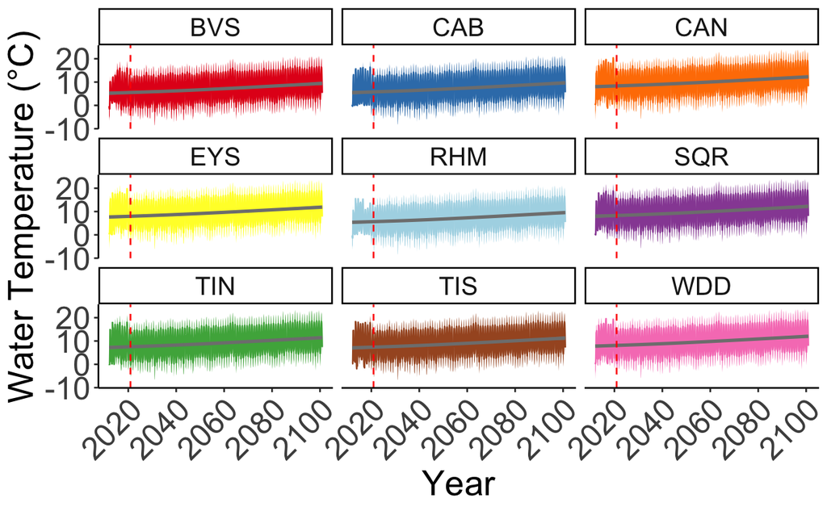

```r
write.csv(Mod_CRD85, "Mod_CRD85.csv")

# Define the custom color palette
CR_colors <- c("#E41A1C", "#377EB8", "#4DAF4A", "#984EA3", "#FF7F00", "#FFFF33", "#A65628", "#F781BF", "lightblue")

# Ensure that CR_colors has the same length as the number of unique ponds
unique_ponds <- unique(Mod_CRD85$pond_name)
if (length(CR_colors) != length(unique_ponds)) {
  stop("The number of colors in CR_colors does not match the number of unique ponds.")
}

# Create a named vector for CR_colors with pond names
color_mapping <- setNames(CR_colors, unique_ponds)

# Plotting
Ponds_CRD85 <- ggplot(data = Mod_CRD85, aes(x = time)) +
  geom_ribbon(aes(ymin = low, ymax = high, fill = pond_name)) +  # Add the ribbon with colors
  geom_line(aes(y = med, color = pond_name)) +  # Ensure lines are visible and colored by pond
  geom_smooth(aes(y = med, color = "grey"), size = 1) +  # Ensure lines are visible and colored by pond
  geom_vline(xintercept = as.Date("2020-12-01"), linetype = "dashed", color = "red") +  # Add vertical dashed red line
  facet_wrap(~ pond_name) +  # Facet by pond_name
  scale_color_manual(values = color_mapping) +  # Use custom colors for lines
  scale_fill_manual(values = color_mapping) +   # Use custom colors for ribbons
  xlab("Year") +
  ylab("Water Temperature (°C)") +
  theme_classic() +
  theme(plot.title = element_text(hjust = 0.5, size = 24),
        axis.title = element_text(size = 22),
        axis.text = element_text(size = 20),
        axis.text.x = element_text(angle = 45, hjust = 1),
        legend.position = "none",
        strip.text = element_text(size = 16))
Ponds_CRD85
ggsave("IndPonds_CRD85.png", plot = Ponds_CRD85, width = 8, height = 6)
```

2. trend by pond (geom smooth for each pond on the same plot for comparison)

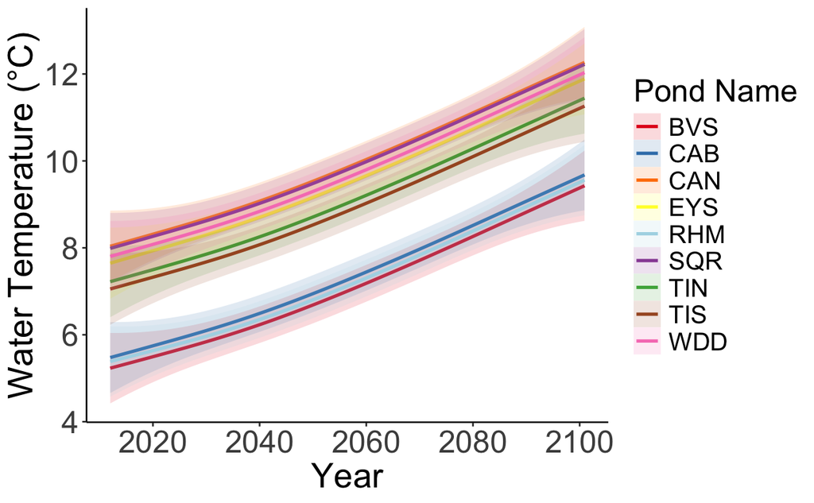

```r
# using the same aestetics as above

Trends_CRD85 <- ggplot(data = Mod_CRD85, aes(x = time)) +
  geom_smooth(aes(y = med, color = pond_name, fill = pond_name), alpha = 0.15, size = 1) +  # Smooth lines with colors by pond_name
  scale_color_manual(values = color_mapping) +
  scale_fill_manual(values = color_mapping) +   # Use custom colors for ribbons
  labs(
       x = "Year",
       y = "Water Temperature (°C)",
       color = "Pond Name",
       fill = "Pond Name") +  # Labels for legend
  theme_classic() +
  theme(plot.title = element_text(hjust = 0.5, size = 18),
        axis.title = element_text(size = 22),
        axis.text = element_text(size = 20),
        legend.position = "right",
        legend.text = element_text(size = 16), # Change the legend text size here
        legend.title = element_text(size = 20))
Trends_CRD85
ggsave("IndTrends_CRD85.png", plot = Trends_CRD85, width = 9, height = 6)
```

3. probability plot (by pond)

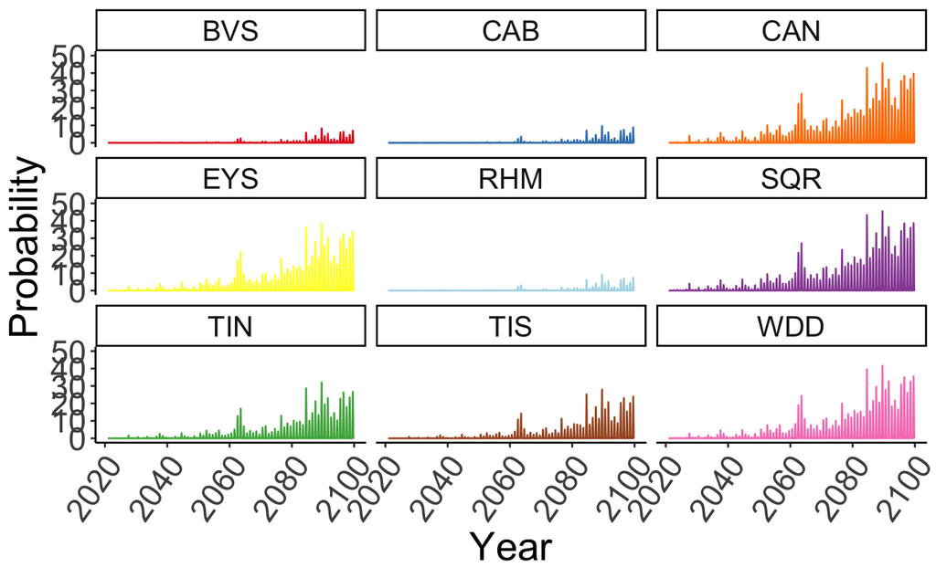

```r
probs_CRD85 <- threshold_probs_mapped
write.csv(probs_CRD85, "probs_CRD85.csv")

Probs20_CRD85 <- ggplot(data = probs_CRD85, aes(x = time)) +
  geom_line(aes(y = prob, color = pond_name)) +  # Ensure lines are visible and colored by pond
  facet_wrap(~ pond_name) +  # Facet by pond_name
  scale_color_manual(values = color_mapping) +  # Use custom colors for lines
  xlab("Year") +
  ylab("Probability") +
  xlim(as.Date(c("2020-12-01", "2099-12-01"))) +
  ylim(0,50) +
  theme_classic() +
  theme(plot.title = element_text(hjust = 0.5, size = 18),
        axis.title = element_text(size = 22),
        axis.text = element_text(size = 18),
        axis.text.x = element_text(angle = 55, hjust = 1),
        legend.position = "none",
        strip.text = element_text(size = 16))
Probs20_CRD85
ggsave("Probs20_CRD85.png", plot = Probs20_CRD85, width = 9, height = 6)
```

4. Model fits by pond

```r
Mod_CRD85
```

| pond | low | med | high | time | pond_name |
| --- | --- | --- | --- | --- | --- |
| 1 | -6.53986855 | -0.32526757 | 5.699089 | 2012-01-01 | BVS |
| 1 | 6.28000000 | 6.28000000 | 6.280000 | 2012-10-01 | BVS |
| 1 | -2.18716469 | 1.77662462 | 5.603523 | 2020-04-01 | BVS |
| 1 | 0.98292775 | 5.59790835 | 10.139153 | 2095-04-01 | BVS |
| 1 | 4.01669348 | 8.53717043 | 13.094550 | 2095-05-01 | BVS |
| 1 | 6.56568725 | 12.44587504 | 18.437048 | 2095-06-01 | BVS |
| 1 | 10.08919286 | 15.11644658 | 20.238681 | 2095-07-01 | BVS |
| 1 | 11.71959337 | 16.22875249 | 20.921658 | 2095-08-01 | BVS |
| 1 | 10.93711456 | 15.21116800 | 19.635433 | 2095-09-01 | BVS |
| 1 | 8.22690073 | 12.24474521 | 16.286308 | 2095-10-01 | BVS |

[output cut: 990 more lines]

```r
ModObs <- Mod_CRD85 %>%
  filter(time < "2021-01-01")
range(ModObs$time)
```

```
[1] "2012-01-01" "2020-12-01"
```

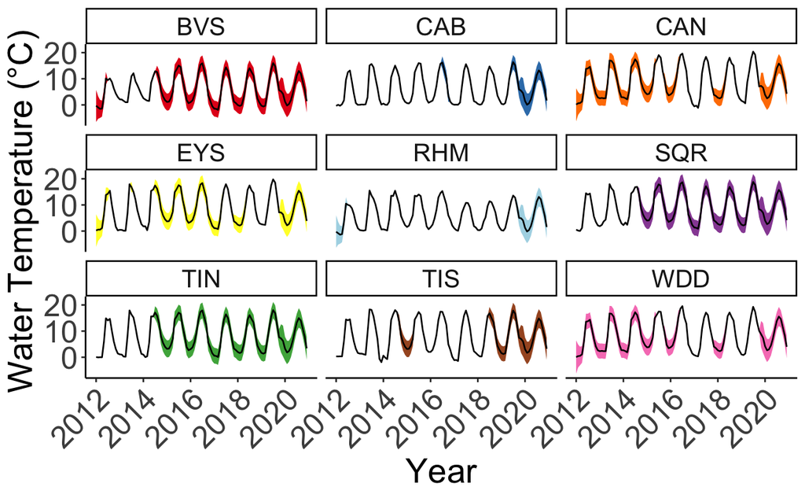

```r
ModelErrorPlot_CRD85 <- ggplot(data = ModObs, aes(x = time)) +
  geom_ribbon(aes(ymin = low, ymax = high, fill = pond_name)) +  # Adjust fill colors
  geom_line(aes(y = med), color = "black") +  # Black lines for the median values
  facet_wrap(~ pond_name) +  # Facet by pond_name
  scale_fill_manual(values = color_mapping) +  # Apply custom color palette for ribbons
  labs(
       x = "Year",
       y = "Water Temperature (°C)",
       color = "Pond Name",
       fill = "Pond Name") +  # Labels for legend
  theme_classic() +
  theme(plot.title = element_text(hjust = 0.5, size = 24),
        axis.title = element_text(size = 22),
        axis.text = element_text(size = 20),
        axis.text.x = element_text(angle = 45, hjust = 1),
        legend.position = "none",
        strip.text = element_text(size = 16))
ModelErrorPlot_CRD85

ggsave("Error_CRD85.png", plot = ModelErrorPlot_CRD85, width = 9, height = 6)
```

```r
CAN_NSE
```

[output not shown]

Clear out the environment and reload the basics before starting the next section

```r
rm(list = ls())

library(tidyverse)
library(rjags)
library(ggplot2)

set.seed(1)
```

# Continueing with Yakutat Forelands (YF)

## RCP 4.5

### Design the Model

Then separate the data into air and water temperature files

```r
# Air and water temperature data: YF loccation, 4.5 scenario
YF_Temps <- read.csv("YF_45SNAPForecast.csv", header=TRUE)

# Air temperature variables
YF_AirTemp45 <- YF_Temps %>%
  select(date, Airport, Air_MonthAvg, std, precision, Region)

# Water temperature variables
YF_WaterTemp45 <- YF_Temps %>%
  select(date, MP1, MP3, MP5, MP8, PL1, PL2, PL3, UBP1, UBP2, UBP3, UBP4)


# Set up a string of all the dates
time <- YF_WaterTemp45$date
length(time)
```

Setting up the random walk model

```r
dlm_pooled <- "
model{
#### Priors
for(p in 1:np){
x[1,p] ~ dnorm(x_ic, tau_ic) # Initial condition of water temperature
}
tau_obs ~ dgamma(a_obs, r_obs) # Prior on observation error
tau_add ~ dgamma(a_add, r_add) # Prior on process error

#### Fixed Effects
beta ~ dmnorm(mu_beta, tau_beta) # Prior on beta coefficients

for(p in 1:np){
int[p] ~ dnorm(mu_int, tau_int) # Prior on pond-specific intercepts
}

#### Data Model
for(t in 1:n){ # loop over all time steps
for(p in 1:np){
OBS[t,p] ~ dnorm(x[t,p], tau_obs) # Observed water temperature is drawn from latent air temperature with observation uncertainty
}
Xf[t] ~ dnorm(muAirTemp[t], tauAirTemp[t]) # Latent air temperature is drawn from mean and precision of forecasated air temperature
}

#### Process Model
for(t in 2:n){ # loop over all time steps except teh first (we defined ic above)
for(p in 1:np){
mu[t,p] <- x[t-1,p] + int[p] + beta[1] * x[t-1,p] + beta[2] * Xf[t] # Mean water temperature is a function of the previous time step and current air temperature
x[t,p] ~ dnorm(mu[t,p], tau_add) # Latent water temperature is drawn from mean water temperature with process uncertainty
}
}
}
"
```

Define the data and priors for the model

```r
# Empty list
data <- list()
# Water temperature observations
data$OBS <- dplyr::select(YF_WaterTemp45, -date)
# Number of time steps
data$n <- nrow(data$OBS)
# Number of ponds
data$np <- ncol(data$OBS)
# Initial water temperature mean
data$x_ic <- 0.1
# Initial water temperature precision
data$tau_ic = 0.1
# Prior parameters for observation and process uncertainty
data$a_obs = 1
data$r_obs = 1
data$a_add = 1
data$r_add = 1
# Prior parameters for beta coefficients
data$mu_beta <- c(0, 0)
data$tau_beta <- diag(x = c(0.001, 0.001), nrow = 2, ncol = 2)
# Prior parameters for intercept
data$mu_int <- 0
data$tau_int <- 0.001
# Mean air temperature estimate
data$muAirTemp <- YF_AirTemp45$Air_MonthAvg
# Air temperature precision
data$tauAirTemp <- YF_AirTemp45$precision
```

Create JAGS model with 3 chains

```r
jm <- jags.model(file = textConnection(dlm_pooled), data = data, n.chains = 3)
```

Posterior samples of parameters

```r
YF45_out_params <- coda.samples(model = jm,
                               variable.names = c('beta', 'int',
                                                  'tau_add', 'tau_obs'),
                               n.iter = 100000, thin = 25)
```

Posterior samples of response variables

```r
YF45_out_response <- coda.samples(model = jm,
                                 variable.names = c('x', 'OBS'),
                                 n.iter = 100000, thin = 25)
```

A couple quick checks here

```r
# plot(YF45_out_params)
gelman.diag(YF45_out_params, confidence = 0.99)
```

Visualize the output by just looking at the **95% credible interval of the time-series of X’s** and compare that to the observed Y’s

Transform the samples back from the log domain to the linear domain

```r
time                               ## adjust to zoom in and out
time <-as.Date(time)
out <- as.matrix(YF45_out_response)         ## convert from coda to matrix
```

code from AMW for splitting up this matrix

```r
x_cols <- grep('^x', colnames(out))
obs_cols <- grep('^OBS', colnames(out))

out_x <- out[,x_cols]
out_obs <- out[,obs_cols]

rm(out)

out_x <- t(out_x)

out_x <- as.data.frame(out_x)
out_x2 <- out_x |>
  tibble::rownames_to_column(var = 'time_pond') |>
  dplyr::mutate(timestep = sub(x = time_pond,
                               pattern = '.*x\\[',
                               replacement = ''),
                timestep = sub(x = timestep,
                               pattern = ',.*',
                               replacement = ''),
                pond = sub(x = time_pond,
                           pattern = '.*,',
                           replacement = ''),
                pond = sub(x = pond,
                           pattern = '\\]',
                           replacement = '')) |>
  tidyr::pivot_longer(-c(time_pond, timestep, pond),
                      names_to = 'iter', values_to = 'val') |>
  dplyr::group_by(pond, timestep) |>
  dplyr::summarize(low = quantile(val, probs = 0.025),
                   med = median(val),
                   high = quantile(val, probs = 0.975))

timesteps <- as.data.frame(time)
timesteps$ind <- as.character(seq(from = 1, to = nrow(timesteps), by = 1))
colnames(timesteps) <- c('time', 'timestep')

ponds <- as.data.frame(colnames(YF_WaterTemp45[-1]))
ponds$ind <- as.character(seq(from = 1, to = nrow(ponds), by = 1))
colnames(ponds) <- c('pond_name', 'pond')

out_x_mapped <- out_x2 |>
  dplyr::left_join(y = timesteps, by = 'timestep') |>
  dplyr::left_join(y = ponds, by = 'pond') |>
  dplyr::select(low, med, high, time, pond_name)

pX <- out_x_mapped |>
  ggplot2::ggplot() +
  ggplot2::geom_line(ggplot2::aes(x = time, y = med)) +
  ggplot2::geom_ribbon(ggplot2::aes(x = time, ymin = low, ymax = high)) +
  ggplot2::facet_wrap(~pond_name)

out_obs <- t(out_obs)

out_obs <- as.data.frame(out_obs)

out_obs2 <- out_obs |>
  tibble::rownames_to_column(var = 'time_pond') |>
  dplyr::mutate(timestep = sub(x = time_pond,
                               pattern = '.*OBS\\[',
                               replacement = ''),
                timestep = sub(x = timestep,
                               pattern = ',.*',
                               replacement = ''),
                pond = sub(x = time_pond,
                           pattern = '.*,',
                           replacement = ''),
                pond = sub(x = pond,
                           pattern = '\\]',
                           replacement = '')) |>
  tidyr::pivot_longer(-c(time_pond, timestep, pond),
                      names_to = 'iter', values_to = 'val') |>
  dplyr::group_by(pond, timestep) |>
  dplyr::summarize(low = quantile(val, probs = 0.025),
                   med = median(val),
                   high = quantile(val, probs = 0.975))

out_obs_mapped <- out_obs2 |>
  dplyr::left_join(y = timesteps, by = 'timestep') |>
  dplyr::left_join(y = ponds, by = 'pond') |>
  dplyr::select(low, med, high, time, pond_name)

pOBS <- out_obs_mapped |>
  ggplot2::ggplot() +
  ggplot2::geom_line(ggplot2::aes(x = time, y = med)) +
  ggplot2::geom_ribbon(ggplot2::aes(x = time, ymin = low, ymax = high)) +
  ggplot2::facet_wrap(~pond_name)

cowplot::plot_grid(pX, pOBS)
```

### Probability of Crossing Threshold

```r
threshold_probs <- out_obs |>
  tibble::rownames_to_column(var = 'time_pond') |>
  dplyr::mutate(timestep = sub(x = time_pond,
                               pattern = '.*OBS\\[',
                               replacement = ''),
                timestep = sub(x = timestep,
                               pattern = ',.*',
                               replacement = ''),
                pond = sub(x = time_pond,
                           pattern = '.*,',
                           replacement = ''),
                pond = sub(x = pond,
                           pattern = '\\]',
                           replacement = '')) |>
  tidyr::pivot_longer(-c(time_pond, timestep, pond),
                      names_to = 'iter', values_to = 'val') |>
  dplyr::group_by(pond, timestep) |>
  dplyr::summarize(n_iter = dplyr::n(),
                   n_thresh = sum(val > 20),
                   prob = (n_thresh / n_iter) * 100)

threshold_probs_mapped <- threshold_probs |>
  dplyr::left_join(y = timesteps, by = 'timestep') |>
  dplyr::left_join(y = ponds, by = 'pond')

threshold_probs_mapped |>
  ggplot2::ggplot() +
  ggplot2::geom_line(ggplot2::aes(x = time, y = prob)) +
  ggplot2::facet_wrap(~pond_name)
```

Save these ouputs using a .RDataFile type

```r
save.image(file = "PooledMod_YF45.RData")

#Currently this has all the information in it. Eventually could limit this to be just the relavent information for the remaining code below
```

### Making Graphs

Load in this file here as long as no code changes are needed above

```r
load(file = "PooledMod_YF45.RData")
```

Creating some nice plots of these

1. colored panel plot (each ponds forecast with the median, high, and low plus a trend line)

```r
# set up the colors here for the plots below so that each pond has the same color each time
Mod_YF45 <- out_obs_mapped
str(Mod_YF45)
write.csv(Mod_YF45, "Mod_YF45.csv")

# Define the custom color palette
YF_colors <- c("#E41A1C", "#377EB8", "#4DAF4A", "#984EA3", "#FF7F00", "#FFFF33", "#A65628", "#F781BF", "lightblue", "lightgreen", "#6A3D9A")

# Ensure that YF_colors has the same length as the number of unique ponds
unique_ponds <- unique(Mod_YF45$pond_name)
if (length(YF_colors) != length(unique_ponds)) {
  stop("The number of colors in YF_colors does not match the number of unique ponds.")
}

# Create a named vector for YF_colors with pond names
color_mapping <- setNames(YF_colors, unique_ponds)

# Plotting
Ponds_YF45 <- ggplot(data = Mod_YF45, aes(x = time)) +
  geom_ribbon(aes(ymin = low, ymax = high, fill = pond_name)) +  # Add the ribbon with colors
  geom_line(aes(y = med, color = pond_name)) +  # Ensure lines are visible and colored by pond
  geom_smooth(aes(y = med, color = "grey"), size = 1) +  # Ensure lines are visible and colored by pond
  geom_vline(xintercept = as.Date("2020-12-01"), linetype = "dashed", color = "red") +  # Add vertical dashed red line
  facet_wrap(~ pond_name) +  # Facet by pond_name
  scale_color_manual(values = color_mapping) +  # Use custom colors for lines
  scale_fill_manual(values = color_mapping) +   # Use custom colors for ribbons
  xlab("Year") +
  ylab("Water Temperature (°C)") +
  theme_classic() +
  theme(plot.title = element_text(hjust = 0.5, size = 24),
        axis.title = element_text(size = 22),
        axis.text = element_text(size = 20),
        axis.text.x = element_text(angle = 45, hjust = 1),
        legend.position = "none",
        strip.text = element_text(size = 16))
Ponds_YF45

ggsave("IndPonds_YF45.png", plot = Ponds_YF45, width = 8, height = 6)
```

2. Trend by pond (geom smooth for each pond on the same plot for comparison)

```r
# using the same aestetics as above

Trends_YF45 <- ggplot(data = Mod_YF45, aes(x = time)) +
  geom_smooth(aes(y = med, color = pond_name, fill = pond_name), alpha = 0.15, size = 1) +  # Smooth lines with colors by pond_name
  scale_color_manual(values = color_mapping) +
  scale_fill_manual(values = color_mapping) +   # Use custom colors for ribbons
  labs(
       x = "Year",
       y = "Water Temperature (°C)",
       color = "Pond Name",
       fill = "Pond Name") +  # Labels for legend
  theme_classic() +
  theme(plot.title = element_text(hjust = 0.5, size = 18),
        axis.title = element_text(size = 22),
        axis.text = element_text(size = 20),
        legend.position = "right",
        legend.text = element_text(size = 16), # Change the legend text size here
        legend.title = element_text(size = 20))
Trends_YF45

ggsave("IndTrends_YF45.png", plot = Trends_YF45, width = 9, height = 6)
```

3. probability plot (by pond)

```r
probs_YF45 <- threshold_probs_mapped
write.csv(probs_YF45, "probs_YF45.csv")

Probs20_YF45 <- ggplot(data = probs_YF45, aes(x = time)) +
  geom_line(aes(y = prob, color = pond_name)) +  # Ensure lines are visible and colored by pond
  facet_wrap(~ pond_name) +  # Facet by pond_name
  scale_color_manual(values = color_mapping) +  # Use custom colors for lines
  xlab("Year") +
  ylab("Probability") +
  xlim(as.Date(c("2020-12-01", "2099-12-01"))) +
  ylim(0,50) +
  theme_classic() +
  theme(plot.title = element_text(hjust = 0.5, size = 24),
        axis.title = element_text(size = 22),
        axis.text = element_text(size = 20),
        axis.text.x = element_text(angle = 45, hjust = 1),
        legend.position = "none",
        strip.text = element_text(size = 16))
Probs20_YF45

ggsave("Probs20_YF45.png", plot = Probs20_YF45, width = 10, height = 6)
```

4. Model fits by pond

```r
Mod_YF45

ModObs <- Mod_YF45 %>%
  filter(time < "2021-01-01")
range(ModObs$time)

ErrorPlot_YF45 <- ggplot(data = ModObs, aes(x = time)) +
  geom_ribbon(aes(ymin = low, ymax = high, fill = pond_name)) +  # Adjust fill colors
  geom_line(aes(y = med), color = "black") +  # Black lines for the median values
  facet_wrap(~ pond_name) +  # Facet by pond_name
  scale_fill_manual(values = color_mapping) +  # Apply custom color palette for ribbons
  labs(
       x = "Year",
       y = "Water Temperature (°C)",
       color = "Pond Name",
       fill = "Pond Name") +  # Labels for legend
  theme_classic() +
  theme(
    plot.title = element_text(hjust = 0.5),
    axis.title = element_text(size = 22),
    axis.text = element_text(size = 20),
    axis.text.x = element_text(angle = 45, hjust = 1),
    legend.position = "none" # Angle x-axis labels if needed
  )
ErrorPlot_YF45

ggsave("Error_YF45.png", plot = ErrorPlot_YF45, width = 9, height = 6)
```

Clear out the environment and reload the basics before starting the next section

```r
rm(list = ls())

library(tidyverse)
library(rjags)
library(ggplot2)

set.seed(1)
```

## RCP 8.5

### Design the Model

Then separate the data into air and water temperature files

```r
# Air and water temperature data: YF loccation, 4.5 scenario
YF_Temps <- read.csv("YF_85SNAPForecast.csv", header=TRUE)

# Air temperature variables
YF_AirTemp85 <- YF_Temps %>%
  select(date, Airport, Air_MonthAvg, std, precision, Region)

# Water temperature variables
YF_WaterTemp85 <- YF_Temps %>%
  select(date, MP1, MP3, MP5, MP8, PL1, PL2, PL3, UBP1, UBP2, UBP3, UBP4)


# Set up a string of all the dates
time <- YF_WaterTemp85$date
length(time)
```

Setting up the random walk model

```r
dlm_pooled <- "
model{
#### Priors
for(p in 1:np){
x[1,p] ~ dnorm(x_ic, tau_ic) # Initial condition of water temperature
}
tau_obs ~ dgamma(a_obs, r_obs) # Prior on observation error
tau_add ~ dgamma(a_add, r_add) # Prior on process error

#### Fixed Effects
beta ~ dmnorm(mu_beta, tau_beta) # Prior on beta coefficients

for(p in 1:np){
int[p] ~ dnorm(mu_int, tau_int) # Prior on pond-specific intercepts
}

#### Data Model
for(t in 1:n){ # loop over all time steps
for(p in 1:np){
OBS[t,p] ~ dnorm(x[t,p], tau_obs) # Observed water temperature is drawn from latent air temperature with observation uncertainty
}
Xf[t] ~ dnorm(muAirTemp[t], tauAirTemp[t]) # Latent air temperature is drawn from mean and precision of forecasated air temperature
}

#### Process Model
for(t in 2:n){ # loop over all time steps except teh first (we defined ic above)
for(p in 1:np){
mu[t,p] <- x[t-1,p] + int[p] + beta[1] * x[t-1,p] + beta[2] * Xf[t] # Mean water temperature is a function of the previous time step and current air temperature
x[t,p] ~ dnorm(mu[t,p], tau_add) # Latent water temperature is drawn from mean water temperature with process uncertainty
}
}
}
"
```

Define the data and priors for the model

```r
# Empty list
data <- list()
# Water temperature observations
data$OBS <- dplyr::select(YF_WaterTemp85, -date)
# Number of time steps
data$n <- nrow(data$OBS)
# Number of ponds
data$np <- ncol(data$OBS)
# Initial water temperature mean
data$x_ic <- 0.1
# Initial water temperature precision
data$tau_ic = 0.1
# Prior parameters for observation and process uncertainty
data$a_obs = 1
data$r_obs = 1
data$a_add = 1
data$r_add = 1
# Prior parameters for beta coefficients
data$mu_beta <- c(0, 0)
data$tau_beta <- diag(x = c(0.001, 0.001), nrow = 2, ncol = 2)
# Prior parameters for intercept
data$mu_int <- 0
data$tau_int <- 0.001
# Mean air temperature estimate
data$muAirTemp <- YF_AirTemp85$Air_MonthAvg
# Air temperature precision
data$tauAirTemp <- YF_AirTemp85$precision
```

Create JAGS model with 3 chains

```r
jm <- jags.model(file = textConnection(dlm_pooled), data = data, n.chains = 3)
```

Posterior samples of parameters

```r
YF85_out_params <- coda.samples(model = jm,
                               variable.names = c('beta', 'int',
                                                  'tau_add', 'tau_obs'),
                               n.iter = 50000, thin = 25)
```

Posterior samples of response variables

```r
YF85_out_response <- coda.samples(model = jm,
                                 variable.names = c('x', 'OBS'),
                                 n.iter = 100000, thin = 25)
```

A couple quick checks here

```r
# plot(YF85_out_params)
gelman.diag(YF85_out_params, confidence = 0.99)
```

Visualize the output by just looking at the **95% Credible interval of the time-series of X’s** and compare that to the observed Y’s

Transform the samples back from the log domain to the linear domain

```r
time                               ## adjust to zoom in and out
time <-as.Date(time)
out <- as.matrix(YF85_out_response)         ## convert from coda to matrix
```

code from AMW for splitting up this matrix

```r
x_cols <- grep('^x', colnames(out))
obs_cols <- grep('^OBS', colnames(out))

out_x <- out[,x_cols]
out_obs <- out[,obs_cols]

rm(out)

out_x <- t(out_x)

out_x <- as.data.frame(out_x)
out_x2 <- out_x |>
  tibble::rownames_to_column(var = 'time_pond') |>
  dplyr::mutate(timestep = sub(x = time_pond,
                               pattern = '.*x\\[',
                               replacement = ''),
                timestep = sub(x = timestep,
                               pattern = ',.*',
                               replacement = ''),
                pond = sub(x = time_pond,
                           pattern = '.*,',
                           replacement = ''),
                pond = sub(x = pond,
                           pattern = '\\]',
                           replacement = '')) |>
  tidyr::pivot_longer(-c(time_pond, timestep, pond),
                      names_to = 'iter', values_to = 'val') |>
  dplyr::group_by(pond, timestep) |>
  dplyr::summarize(low = quantile(val, probs = 0.025),
                   med = median(val),
                   high = quantile(val, probs = 0.975))

timesteps <- as.data.frame(time)
timesteps$ind <- as.character(seq(from = 1, to = nrow(timesteps), by = 1))
colnames(timesteps) <- c('time', 'timestep')

ponds <- as.data.frame(colnames(YF_WaterTemp85[-1]))
ponds$ind <- as.character(seq(from = 1, to = nrow(ponds), by = 1))
colnames(ponds) <- c('pond_name', 'pond')

out_x_mapped <- out_x2 |>
  dplyr::left_join(y = timesteps, by = 'timestep') |>
  dplyr::left_join(y = ponds, by = 'pond') |>
  dplyr::select(low, med, high, time, pond_name)

pX <- out_x_mapped |>
  ggplot2::ggplot() +
  ggplot2::geom_line(ggplot2::aes(x = time, y = med)) +
  ggplot2::geom_ribbon(ggplot2::aes(x = time, ymin = low, ymax = high)) +
  ggplot2::facet_wrap(~pond_name)

out_obs <- t(out_obs)

out_obs <- as.data.frame(out_obs)

out_obs2 <- out_obs |>
  tibble::rownames_to_column(var = 'time_pond') |>
  dplyr::mutate(timestep = sub(x = time_pond,
                               pattern = '.*OBS\\[',
                               replacement = ''),
                timestep = sub(x = timestep,
                               pattern = ',.*',
                               replacement = ''),
                pond = sub(x = time_pond,
                           pattern = '.*,',
                           replacement = ''),
                pond = sub(x = pond,
                           pattern = '\\]',
                           replacement = '')) |>
  tidyr::pivot_longer(-c(time_pond, timestep, pond),
                      names_to = 'iter', values_to = 'val') |>
  dplyr::group_by(pond, timestep) |>
  dplyr::summarize(low = quantile(val, probs = 0.025),
                   med = median(val),
                   high = quantile(val, probs = 0.975))

out_obs_mapped <- out_obs2 |>
  dplyr::left_join(y = timesteps, by = 'timestep') |>
  dplyr::left_join(y = ponds, by = 'pond') |>
  dplyr::select(low, med, high, time, pond_name)

pOBS <- out_obs_mapped |>
  ggplot2::ggplot() +
  ggplot2::geom_line(ggplot2::aes(x = time, y = med)) +
  ggplot2::geom_ribbon(ggplot2::aes(x = time, ymin = low, ymax = high)) +
  ggplot2::facet_wrap(~pond_name)

cowplot::plot_grid(pX, pOBS)
```

### Probability of Crossing Threshold

```r
threshold_probs <- out_obs |>
  tibble::rownames_to_column(var = 'time_pond') |>
  dplyr::mutate(timestep = sub(x = time_pond,
                               pattern = '.*OBS\\[',
                               replacement = ''),
                timestep = sub(x = timestep,
                               pattern = ',.*',
                               replacement = ''),
                pond = sub(x = time_pond,
                           pattern = '.*,',
                           replacement = ''),
                pond = sub(x = pond,
                           pattern = '\\]',
                           replacement = '')) |>
  tidyr::pivot_longer(-c(time_pond, timestep, pond),
                      names_to = 'iter', values_to = 'val') |>
  dplyr::group_by(pond, timestep) |>
  dplyr::summarize(n_iter = dplyr::n(),
                   n_thresh = sum(val > 20),
                   prob = (n_thresh / n_iter) * 100)

threshold_probs_mapped <- threshold_probs |>
  dplyr::left_join(y = timesteps, by = 'timestep') |>
  dplyr::left_join(y = ponds, by = 'pond')

threshold_probs_mapped |>
  ggplot2::ggplot() +
  ggplot2::geom_line(ggplot2::aes(x = time, y = prob)) +
  ggplot2::facet_wrap(~pond_name)
```

Save these ouputs using a .RDataFile type

```r
save.image(file = "PooledMod_YF85.RData")

#Currently this has all the information in it. Eventually could limit this to be just the relavent information for the remaining code below
```

### Making Graphs

Load in this file here as long as no code changes are needed above

```r
load(file = "PooledMod_YF85.RData")
```

Creating some nice plots of these

1. colored panel plot (each ponds forecast with the median, high, and low plus a trend line)

```r
# set up the colors here for the plots below so that each pond has the same color each time
Mod_YF85 <- out_obs_mapped
str(Mod_YF85)
write.csv(Mod_YF85, "Mod_YF85.csv")

# Define the custom color palette
YF_colors <- c("#E41A1C", "#377EB8", "#4DAF4A", "#984EA3", "#FF7F00", "#FFFF33", "#A65628", "#F781BF", "lightblue", "lightgreen", "#6A3D9A")

# Ensure that YF_colors has the same length as the number of unique ponds
unique_ponds <- unique(Mod_YF85$pond_name)
if (length(YF_colors) != length(unique_ponds)) {
  stop("The number of colors in YF_colors does not match the number of unique ponds.")
}

# Create a named vector for YF_colors with pond names
color_mapping <- setNames(YF_colors, unique_ponds)

# Plotting
Ponds_YF85 <- ggplot(data = Mod_YF85, aes(x = time)) +
  geom_ribbon(aes(ymin = low, ymax = high, fill = pond_name)) +  # Add the ribbon with colors
  geom_line(aes(y = med, color = pond_name)) +  # Ensure lines are visible and colored by pond
  geom_smooth(aes(y = med, color = "grey"), size = 1) +  # Ensure lines are visible and colored by pond
  geom_vline(xintercept = as.Date("2020-12-01"), linetype = "dashed", color = "red") +  # Add vertical dashed red line
  facet_wrap(~ pond_name) +  # Facet by pond_name
  scale_color_manual(values = color_mapping) +  # Use custom colors for lines
  scale_fill_manual(values = color_mapping) +   # Use custom colors for ribbons
  xlab("Year") +
  ylab("Water Temperature (°C)") +
  theme_classic() +
  theme(plot.title = element_text(hjust = 0.5, size = 24),
        axis.title = element_text(size = 22),
        axis.text = element_text(size = 20),
        axis.text.x = element_text(angle = 45, hjust = 1),
        legend.position = "none",
        strip.text = element_text(size = 16))
Ponds_YF85

ggsave("IndPonds_YF85.png", plot = Ponds_YF85, width = 8, height = 6)
```

Create plots of the trend by pond (geom smooth for each pond on the same plot for comparison)

```r
# using the same aestetics as above

Trends_YF85 <- ggplot(data = Mod_YF85, aes(x = time)) +
  geom_smooth(aes(y = med, color = pond_name, fill = pond_name), alpha = 0.15, size = 1) +  # Smooth lines with colors by pond_name
  scale_color_manual(values = color_mapping) +
  scale_fill_manual(values = color_mapping) +   # Use custom colors for ribbons
  labs(
       x = "Year",
       y = "Water Temperature (°C)",
       color = "Pond Name",
       fill = "Pond Name") +  # Labels for legend
  theme_classic() +
  theme(plot.title = element_text(hjust = 0.5, size = 18),
        axis.title = element_text(size = 22),
        axis.text = element_text(size = 20),
        legend.position = "right",
        legend.text = element_text(size = 16), # Change the legend text size here
        legend.title = element_text(size = 20))
Trends_YF85

ggsave("IndTrends_YF85.png", plot = Trends_YF85, width = 9, height = 6)
```

3. probability plot (by pond)

```r
probs_YF85 <- threshold_probs_mapped
write.csv(probs_YF85, "probs_YF85.csv")

Probs20_YF85 <- ggplot(data = probs_YF85, aes(x = time)) +
  geom_line(aes(y = prob, color = pond_name)) +  # Ensure lines are visible and colored by pond
  facet_wrap(~ pond_name) +  # Facet by pond_name
  scale_color_manual(values = color_mapping) +  # Use custom colors for lines
  xlab("Year") +
  ylab("Probability") +
  xlim(as.Date(c("2020-12-01", "2099-12-01"))) +
  ylim(0,50) +
  theme_classic() +
  theme(plot.title = element_text(hjust = 0.5, size = 24),
        axis.title = element_text(size = 22),
        axis.text = element_text(size = 20),
        axis.text.x = element_text(angle = 45, hjust = 1),
        legend.position = "none",
        strip.text = element_text(size = 16))
Probs20_YF85

ggsave("Probs20_YF85.png", plot = Probs20_YF85, width = 9, height = 6)
```

4. Model fits by pond

```r
Mod_YF85

ModObs <- Mod_YF85 %>%
  filter(time < "2021-01-01")
range(ModObs$time)

ModelErrorPlot_YF85 <- ggplot(data = ModObs, aes(x = time)) +
  geom_ribbon(aes(ymin = low, ymax = high, fill = pond_name)) +  # Adjust fill colors
  geom_line(aes(y = med), color = "black") +  # Black lines for the median values
  facet_wrap(~ pond_name) +  # Facet by pond_name
  scale_fill_manual(values = color_mapping) +  # Apply custom color palette for ribbons
  labs(
       x = "Year",
       y = "Water Temperature (°C)",
       color = "Pond Name",
       fill = "Pond Name") +  # Labels for legend
  theme_classic() +
  theme(plot.title = element_text(hjust = 0.5, size = 18),
        axis.title = element_text(size = 22),
        axis.text = element_text(size = 20),
        axis.text.x = element_text(angle = 65, hjust = 1),
        legend.position = "none",
        strip.text = element_text(size = 16))
ModelErrorPlot_YF85

ggsave("Error_YF85.png", plot = ModelErrorPlot_YF85, width = 9, height = 6)
```

Clear the environment

```r
rm(list = ls())
```